# HW3-drafting-viz

Author

Lilia Mourier

### **1.** Which option do you plan to pursue? It’s okay if this has changed since HW #1.

I plan to create an infographic with at least three data visualizations, but likely a few more.

### **2.** Restate your question(s). Has this changed at all since HW #1? If yes, how so?

Since HW #1, my questions have completely changed. Initially, I planned to explore coastal access and equity, but after analyzing the data for HW #2, I didn’t find many compelling patterns. Still within the broader theme of coastal resilience, I’ve now decided to examine shoreline armoring along California’s coast instead. My new questions are as follows:

**Overarching Question:**

“How is hard shoreline armoring shaping California’s coast?”

**Sub-Questions:**

1. How much of California’s coastline is armored? (Extent and proportion compared to natural shoreline)
2. Where is hard shoreline armoring most concentrated? (Spatial distribution by region or county)
3. What proportion of armored shoreline is publicly vs. privately owned? (Ownership breakdown)
4. What types of shoreline armoring are most common? (Breakdown by structure type)
5. What is the composition of natural backshore of armored areas? (Beaches, cliffs/bluffs, roads?)

### **3.** Explain which variables from your data set(s) you will use to answer your question(s), and how.

The analytic approach and variables from my data set that I will use to answer each of my questions are noted after each sub question listed below.

1. How much of California’s coastline is armored? (Extent and proportion compared to natural shoreline) — I will sum the ‘length calculation’ variable to determine the total length of armored coastline and compare it to the length of California’s entire coastline.
2. Where is hard shoreline armoring most concentrated? (Spatial distribution by region or county) — I will group observations by the ‘county’ variable, count the total structures per county, join this summarized data with tigris county shapefiles, and use this data to create a heatmap of armoring along California’s coastal counties. I will also plot armoring locations using the latitude and longitute variables.
3. What proportion of armored shoreline is publicly vs. privately owned? (Ownership breakdown) — I will use the ‘development type’ variable to categorize each shoreline structure as either ‘Private’ or ‘Public.’ I will group the data based on these categories, count the number of structures in each group, and calculate the proportion of private versus public armoring along California’s coast.
4. What types of shoreline armoring are most common? (Breakdown by structure type) — I will use the ‘structure type’ variable to group the data by structure type, count the number of structures in each category, and calculate the proportion of each structure type relative to the total.
5. What is the composition of natural backshore of armored areas? (Beaches, cliffs/bluffs, roads?) — I will use the ‘backshore type’ variable to group the data by backshore environment, count the number of structures in each backshore category, and calculate the proportion of each backshore type relative to the total.

### 4. Find at least two data visualizations that you could (potentially) borrow / adapt pieces from. Link to them or download and embed them into your `.qmd` file, and explain which elements you might borrow (e.g. the graphic form, legend design, layout, etc.).

I am really inspired by Sonja Kuijper’s data visualizations. Specifically, Studio Terp’s [The Art of The High Line](https://www.studioterp.nl/the-art-of-the-high-line/) and [Rain Drops - 25 years of precipitation in Eindhoven](https://www.studioterp.nl/rain-drops-a-datavisualization-by-studio-terp/) projects. I really like the creative, yet simple, ways that basic size comparisons are visualized in The Art of the High Line project. For example, the size of each age group being visualized by circle area or the gender proportion being visualized by one thin proportional bar. I may borrow these elements, as well as the creative way to show nested categorical data in columns as done with the art categories data. I also really like the color palette and minimalism of the data visualizations in the Rain Drops project. I plan to base my palette and design off these aesthetics.

### **5.** Hand-draw your anticipated visualizations, then take a photo of your drawing(s) and embed it in your rendered `.qmd` file – **note** that these are not exploratory visualizations, but rather your plan for your final visualizations that you will eventually polish and submit with HW #4.

Below is a mock-up of my infographic:

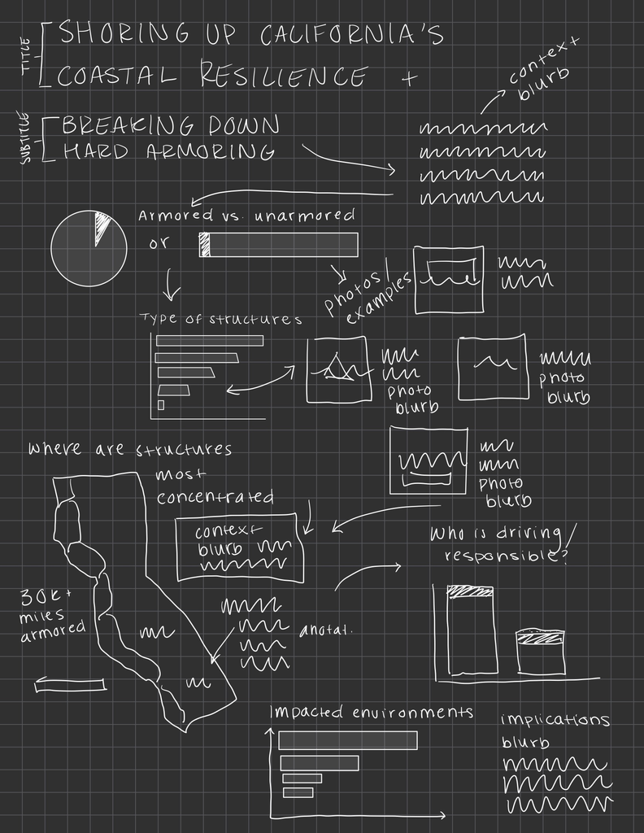

Below are mock-ups of my individual data visualizations:

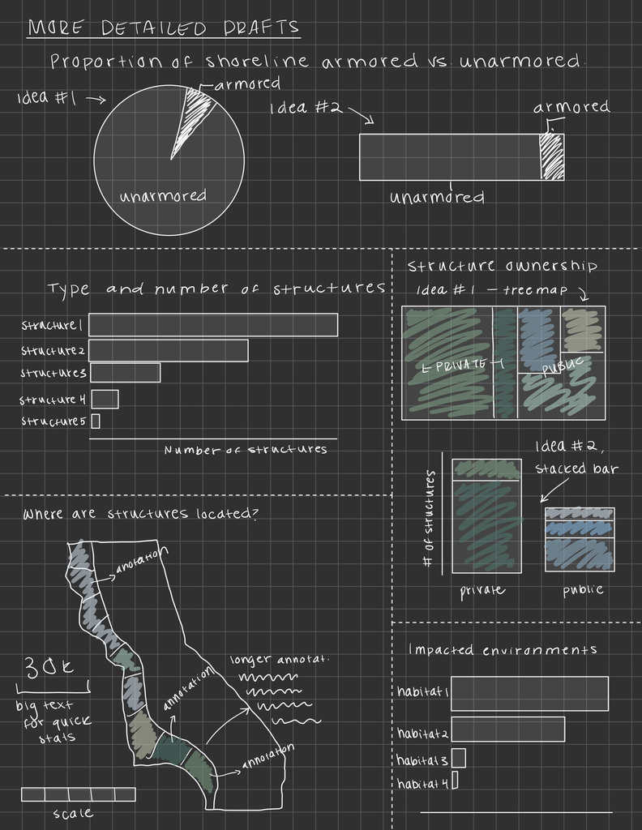

### 6. Mock up **all** of your hand drawn visualizations using code.

Setting up libraries and data for graphing:

```r
##~~~~~~~~~~~~~~~~~~~~~~~~~~~~~~~~~~~~~~~~~~~~~~~~~~~~~~~~~~~~~~~~~~~~~~~~~~~~~~
##                               load libraries                             ----
##~~~~~~~~~~~~~~~~~~~~~~~~~~~~~~~~~~~~~~~~~~~~~~~~~~~~~~~~~~~~~~~~~~~~~~~~~~~~~~

library(tidyverse)
library(janitor)
library(ggtext)
library(sf)
library(tigris)
library(glue)
library(stringr)

##~~~~~~~~~~~~~~~~~~~~~~~~~~~~~~~~~~~~~~~~~~~~~~~~~~~~~~~~~~~~~~~~~~~~~~~~~~~~~~
##                          load & wrangle data                       ----
##~~~~~~~~~~~~~~~~~~~~~~~~~~~~~~~~~~~~~~~~~~~~~~~~~~~~~~~~~~~~~~~~~~~~~~~~~~~~~~

#....................define coastal cities and counties.....................

coastal_counties <- c("Del Norte", "Sonoma", "Humboldt", "Mendocino", "Marin",
                      "San Francisco", "San Mateo", "Santa Cruz", "Monterey",
                      "San Luis Obispo", "Santa Barbara", "Ventura", "Los Angeles",
                      "Orange", "San Diego")

#....................load coastal armoring data...................

# load coastal armoring csv data
coastal_structures <- read_csv(here("data", "structures_2024.csv")) |>
  clean_names()

# load coastal armoring shapefile data
coastal_structures_sf <- read_sf(here("data","structures_2024_sf",
                                      "StructureLocations_2_15_24.shp"))

# summarize coastal armoring structures per county
total_county_structures <- coastal_structures |>
  group_by(county) |>
  summarise(
    total_structures = n(),
    .groups = "drop"
  )

#..............sum total length of armored coastline.............
armored_coastline <- coastal_structures |>
  clean_names() |>
  select(length_calculation) |>
  summarise(
    armored_length = sum(length_calculation)
  ) |>
  mutate(unarmored_length = 4435200 - armored_length) |>
  pivot_longer(
    cols = everything(),
    names_to = "coastline_type",
    values_to = "length_ft"
  ) |>
  mutate(proportion = length_ft/4435200)

#.................wrangle development type data .................

# select and clean development data
structure_development <- coastal_structures |>
  select(development_type) |>
  mutate(development_type = tolower(development_type)) |>
  mutate(development_type = case_when(
    development_type %in% c("public, local", "public, state", "public, federal", "private, commercial") ~ development_type,
    development_type %in% c("privates, residential", "private, residential")
    ~ "private, residential",
    TRUE ~ NA_character_)) |>
  separate(development_type, into = c("ownership_type", "sub_category"), sep = ", ", extra = "merge", fill = "right")

# count development types
development_count <- structure_development |>
  drop_na() |>
  count(ownership_type, sub_category) |>
  arrange(n) |>
  mutate(sub_category = fct_reorder(sub_category, n))

#.................wrangle structure type data .................

# select structure type
structure_type <- coastal_structures |>
  select(structure_type)

# count structure types
structure_count <- structure_type |>
  drop_na() |>
  count(structure_type) |>
  arrange(n) |>
  mutate(structure_type = fct_reorder(structure_type, n))

#.................wrangle backshore type data .................

# select and clean backshore type
backshore_type <- coastal_structures |>
  select(backshore_type) |>
  mutate(backshore_type = case_when(
    backshore_type %in% c("Beach", "Cliff/Bluff", "Inlet","Harbor", "Developed") ~ backshore_type,
    backshore_type %in% c("Bluff")
    ~ "Cliff/Bluff",
    TRUE ~ NA_character_))

# count backshore type
backshore_count <- backshore_type |>
  drop_na() |>
  count(backshore_type) |>
  arrange(n) |>
  mutate(backshore_type = fct_reorder(backshore_type, n))

#.......load state and county boundaries and merge with summary data.......

# define california boundaries
california_sf <- states(cb = TRUE, class = "sf") |>
  filter(STUSPS == "CA")

# filter for coastal counties only
coastal_counties_sf <- counties(state = "CA", cb = TRUE, class = "sf")|>
  mutate(county = sub(" County", "", NAME)) |>
  filter(county %in% coastal_counties)

# Merge with coastal county data
county_structures_sf <- coastal_counties_sf |>
  right_join(total_county_structures, by = "county")
```

Defining figure aesthetics:

```r
##~~~~~~~~~~~~~~~~~~~~~~~~~~~~~~~~~~~~~~~~~~~~~~~~~~~~~~~~~~~~~~~~~~~~~~~~~~~~~~
##                          Define Graphic Aesthetics                       ----
##~~~~~~~~~~~~~~~~~~~~~~~~~~~~~~~~~~~~~~~~~~~~~~~~~~~~~~~~~~~~~~~~~~~~~~~~~~~~~~

# define colors
deep_olive <- "#1e1d18"
dark_olive <- "#383732"
medium_olive <- "#70674D"
light_olive <- "#BCB583"
deep_ice <- "#080d12"
darker_ice <- "#1d2a3a"
dark_ice <- "#3b4a5f"
medium_dark_ice <- "#5c738a"
medium_ice <- "#7992A6"
light_ice <- "#C0D0CE"

# define a custom theme function
theme_dark_ice_olive <- function() {
  theme_minimal() +

  theme(

    # customize text
    text = element_text(family = "Roboto", size = 10, color = "white"),
    axis.text.x = element_text(size = 8, color = "white"),
    axis.text.y = element_text(size = 8, color = "white"),

    # customize grid lines and background
    panel.grid.major = element_blank(),
    panel.grid.minor = element_blank(),

    # axis line and tick marks color customization
    axis.line = element_line(color = "white", size = 0.25),
    axis.ticks = element_line(color = "white", size = 0.25),

    # customize plot title
    plot.title = element_text(family = "Roboto Slab",
                              size = 12, face = "bold",
                              color = "white"),

    # customize plot and panel background
    plot.background = element_rect(fill = deep_olive, color = deep_olive),
    panel.background = element_rect(fill = deep_olive, color = deep_olive),

  )
}
```

Building pie chart of total armored vs unarmored coastline:

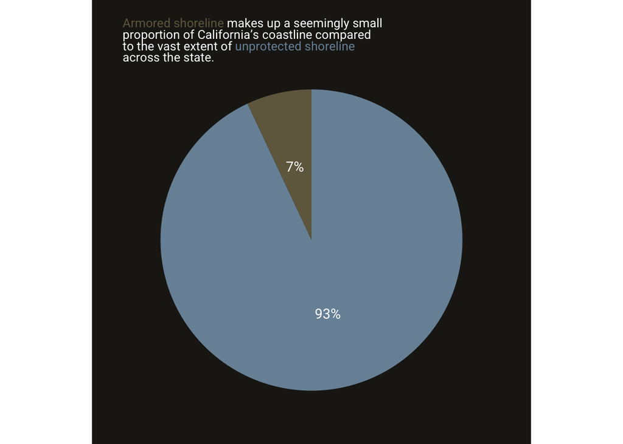

```r
##~~~~~~~~~~~~~~~~~~~~~~~~~~~~~~~~~~~~~~~~~~~~~~~~~~~~~~~~~~~~~~~~~~~~~~~~~~~~~~
##                        Create Proportional Bar Chart                     ----
##~~~~~~~~~~~~~~~~~~~~~~~~~~~~~~~~~~~~~~~~~~~~~~~~~~~~~~~~~~~~~~~~~~~~~~~~~~~~~~

# pice chart subtitle
pie_label <- glue::glue(
  "<span style='color:#70674D; font-weight: bold;'>Armored shoreline</span> makes up a seemingly small<br>proportion of California's coastline compared<br>to the vast extent of <span style='color:#7992A6; font-weight: bold;'>unprotected shoreline</span><br>across the state. "
)

# pie chart
ggplot(armored_coastline, aes(x = '', y = proportion, fill = coastline_type)) +
  geom_bar(stat = "identity", width = .5) +
  scale_fill_manual(values = c("armored_length" = medium_olive, "unarmored_length" = medium_ice)) +
  coord_polar(theta = "y") +
  geom_text(aes(label = scales::percent(proportion)),
            position = position_stack(vjust = 0.5),
            color = "white",
            size = 4,
            family = "Roboto") +
  labs(
    subtitle = pie_label,
    x = NULL,
    y = NULL,
    fill = "Category"
  ) +
  theme_dark_ice_olive() +
  theme(
    legend.position = "none",
    axis.text.x = element_blank(),
    axis.ticks.x = element_blank(),
    axis.line.x = element_blank(),
    axis.line.y = element_blank(),
    axis.ticks.y = element_blank(),
    plot.subtitle = ggtext::element_markdown(margin = margin(t = 5, b = -10)),
    plot.margin = margin(10, 25, 10, 20)
  )
```

Building my nested and stacked development type bar chart:

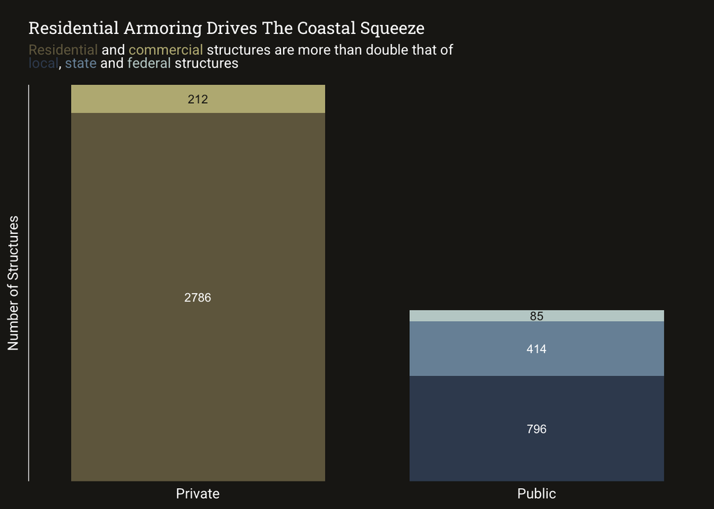

```r
##~~~~~~~~~~~~~~~~~~~~~~~~~~~~~~~~~~~~~~~~~~~~~~~~~~~~~~~~~~~~~~~~~~~~~~~~~~~~~~
##                Create stacked bar chart of development type              ----
##~~~~~~~~~~~~~~~~~~~~~~~~~~~~~~~~~~~~~~~~~~~~~~~~~~~~~~~~~~~~~~~~~~~~~~~~~~~~~~

# development type
development_subtitle <- glue::glue("<span style='color:#70674D; font-weight: bold;'>Residential</span> and <span style='color:#BCB583; font-weight: bold;'>commercial</span> structures are more than double that of <br><span style='color:#3b4a5f; font-weight: bold;'>local</span>, <span style='color:#7992A6; font-weight: bold;'>state</span> and <span style='color:#C0D0CE; font-weight: bold;'>federal</span> structures")

# stacked bar chart
ggplot(development_count, aes(x = ownership_type, y = n, fill = sub_category)) +
  geom_col(width = 0.75) +
  geom_text(aes(
      label = n,
      color = ifelse(sub_category %in% c("commercial", "federal"), "#1e1d18", "white")),
      size = 3, position = position_stack(vjust = 0.5)) +
  scale_fill_manual(values = c(
    "commercial" = light_olive,
    "residential" = medium_olive,
    "federal" = light_ice,
    "local" = dark_ice,
    "state" = medium_ice
  )) +
  scale_color_manual(values = c("#1e1d18" = "#1e1d18", "white" = "white")) +
  labs(title = "Residential Armoring Drives The Coastal Squeeze",
       subtitle = development_subtitle,
       x = NULL,
       y = "Number of Structures") +
  scale_y_continuous(expand = c(0.0, 0.0)) +
  scale_x_discrete(expand = c(0, 0.5),
                   labels = c("private" = "Private", "public" = "Public")) +
  theme_dark_ice_olive() +
  theme(
    legend.position = "blank",
    axis.line.x = element_blank(),
    axis.ticks.x = element_blank(),
    axis.text.x = element_text(size = 10),
    axis.ticks.y = element_blank(),
    axis.text.y = element_blank(),
    plot.subtitle = ggtext::element_markdown(margin = margin(t = 5, b = 10)),
    plot.title = element_text( margin = margin(t = 10, b = 0))
  )
```

Building my structure type bar chart:

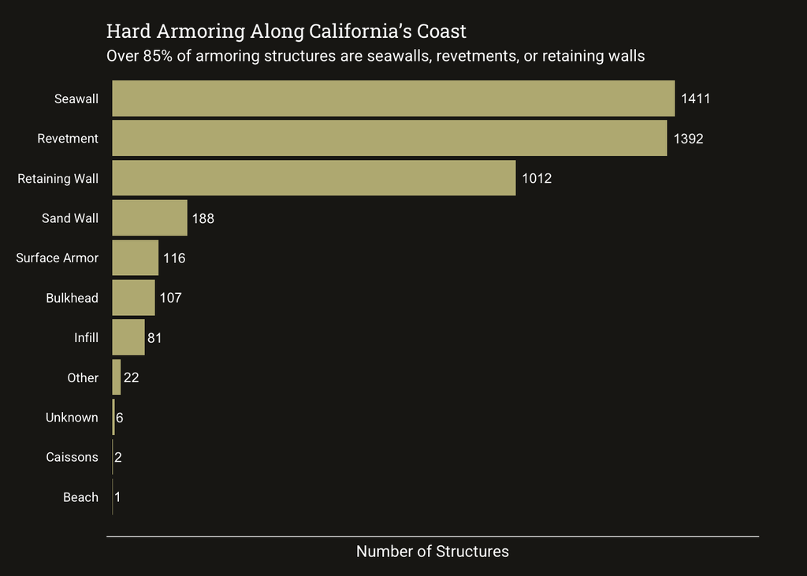

```r
##~~~~~~~~~~~~~~~~~~~~~~~~~~~~~~~~~~~~~~~~~~~~~~~~~~~~~~~~~~~~~~~~~~~~~~~~~~~~~~
##                Create a bar chart of structure type                      ----
##~~~~~~~~~~~~~~~~~~~~~~~~~~~~~~~~~~~~~~~~~~~~~~~~~~~~~~~~~~~~~~~~~~~~~~~~~~~~~~

# bar chart
ggplot(structure_count, aes(x = structure_type, y = n)) +
  geom_col(fill = light_olive) +
  geom_text(aes(
      label = n),
      color = "white",
      size = 3,
      vjust = 0.5,
      hjust = -0.2) +
  labs(title = "Hard Armoring Along California’s Coast",
       subtitle = str_wrap("Over 85% of armoring structures are seawalls, revetments, or retaining walls", width = 30),
       x = NULL,
       y = "Number of Structures"
       ) +
  scale_y_continuous(expand = expansion(mult = c(0.01, 0.15)))+
  scale_x_discrete(expand = expansion(mult = c(0.1, 0.0))) +
  coord_flip() +
  theme_dark_ice_olive() +
  theme(
    legend.position = "blank",
    axis.ticks.x = element_blank(),
    axis.text.x = element_blank(),
    axis.ticks.y = element_blank(),
    axis.text.y = element_text(size = 8),
    axis.line.y = element_blank(),
    plot.subtitle = ggtext::element_markdown(margin = margin(t = 5, b = 10)),
    plot.title = element_text(margin = margin(t = 15, b = 0)),
    plot.margin = margin(0, 30, 10, 10)
  )
```

Building my backshore type bar graph:

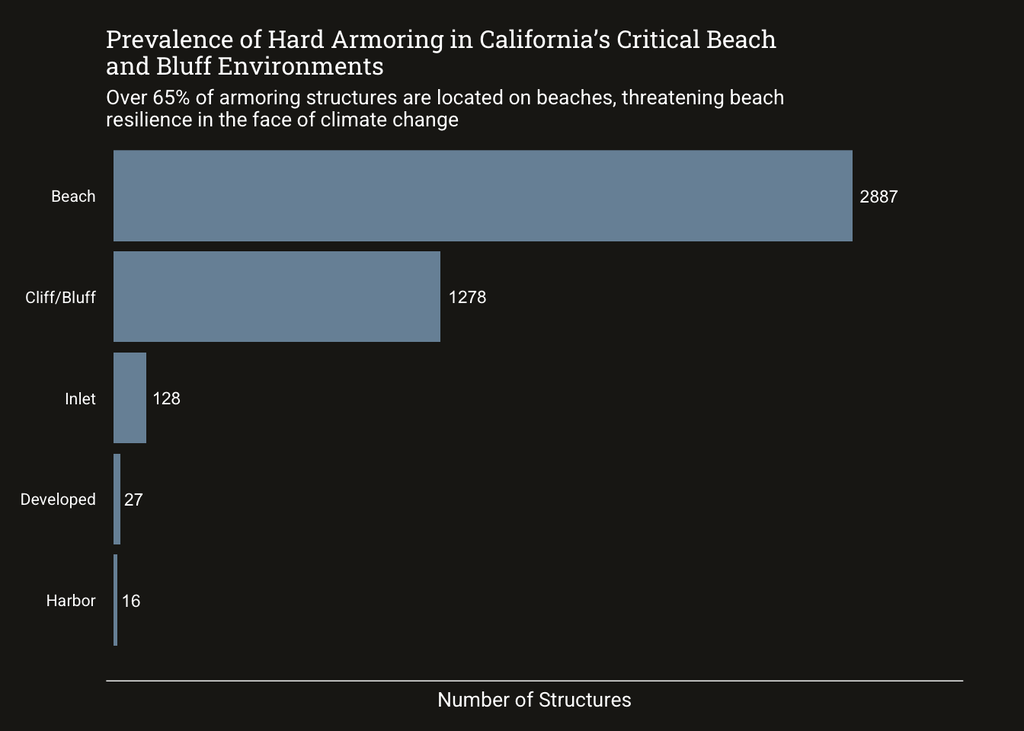

```r
##~~~~~~~~~~~~~~~~~~~~~~~~~~~~~~~~~~~~~~~~~~~~~~~~~~~~~~~~~~~~~~~~~~~~~~~~~~~~~~
##                Create a bar chart of backshore type                      ----
##~~~~~~~~~~~~~~~~~~~~~~~~~~~~~~~~~~~~~~~~~~~~~~~~~~~~~~~~~~~~~~~~~~~~~~~~~~~~~~

# Create the bar chart
ggplot(backshore_count, aes(x = backshore_type, y = n)) +
  geom_col(fill = medium_ice) +
  geom_text(aes(
      label = n),
      color = "white",
      size = 3,
      vjust = 0.5,
      hjust = -0.2) +
  labs(title = str_wrap("Prevalence of Hard Armoring in California’s Critical Beach and Bluff Environments", width = 60),
       subtitle = str_wrap("Over 65% of armoring structures are located on beaches, threatening beach resilience in the face of climate change", width = 75),
       x = NULL,
       y = "Number of Structures",
       ) +
  scale_y_continuous(expand = expansion(mult = c(0.01, 0.15)))+
  scale_x_discrete(expand = expansion(mult = c(0.2, 0.0))) +
  coord_flip() +
  theme_dark_ice_olive() +
  theme(
    legend.position = "blank",
    axis.ticks.x = element_blank(),
    axis.text.x = element_blank(),
    axis.ticks.y = element_blank(),
    axis.text.y = element_text(size = 8),
    axis.line.y = element_blank(),
    plot.subtitle = element_text(margin = margin(t = 5, b = 10)),
    plot.title = element_text(margin = margin(t = 15, b = 0)),
    plot.margin = margin(0, 30, 10, 10)
  )
```

Building my cloropleth map of armoring per coastal county:

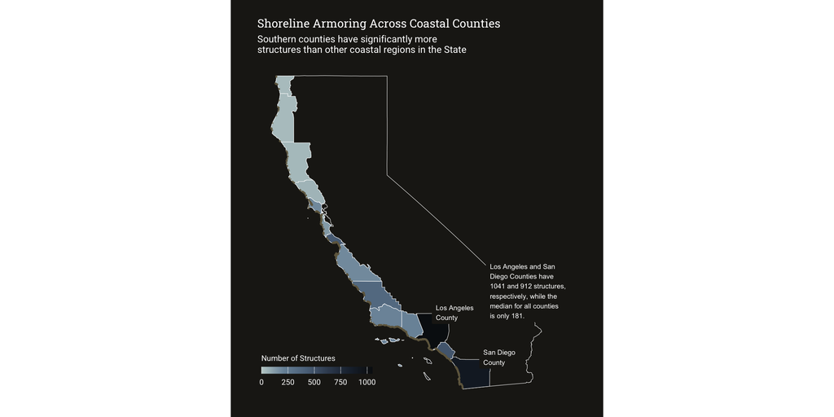

```r
##~~~~~~~~~~~~~~~~~~~~~~~~~~~~~~~~~~~~~~~~~~~~~~~~~~~~~~~~~~~~~~~~~~~~~~~~~~~~~~
##                      Create County Cloropleth Map                        ----
##~~~~~~~~~~~~~~~~~~~~~~~~~~~~~~~~~~~~~~~~~~~~~~~~~~~~~~~~~~~~~~~~~~~~~~~~~~~~~~

# cloropleth map
ggplot() +
  geom_sf(data = california_sf, fill = deep_olive, color = "white") +
  geom_sf(data = county_structures_sf, aes(fill = total_structures), color = "white") +
  scale_fill_gradientn(
    name = "Number of Structures",
    colors = rev(c(deep_ice, darker_ice, dark_ice, medium_dark_ice, medium_ice, light_ice)),
    limits = c(0, 1050)) +
  geom_point(data = coastal_structures, aes(x = longitude, y = latitude), color = medium_olive,
             size = .25, alpha = 0.5) +
  labs(
    title = "Shoreline Armoring Across Coastal Counties",
    subtitle = str_wrap("Southern counties have significantly more structures than other coastal regions in the State", width = 50)
  ) +
  theme_dark_ice_olive() +
  theme(
    legend.position = c(.20, 0.1),
    legend.title.position = "top",
    legend.title = element_text(size = 8),
    legend.direction = "horizontal",
    axis.line = element_blank(),
    axis.ticks = element_blank(),
    axis.text.x = element_blank(),
    axis.text.y = element_blank(),
    axis.title = element_blank(),
    panel.background = element_rect(fill = deep_olive, color = NA),
    plot.background = element_rect(fill = deep_olive, color = NA),
    plot.margin = margin(20, 50, 10, 25)
  ) +
  guides(fill = guide_colorbar(ticks = FALSE, barwidth = 8, barheight = 0.5)) +
    geom_label(
    aes(x = -118.3, y = 34.85, label = "Los Angeles\nCounty"),
    size = 2.5,
    face = "bold",
    color = "white",
    fill = deep_olive,
    label.size = 0,
    label.padding = unit(0.5, "lines"),
    hjust = 0.0,
    vjust = 0.5
  ) +
  geom_label(
    aes(x = -116.5, y = 33.5, label = "San Diego\nCounty"),
    size = 2.5,
    face = "bold",
    color = "white",
    fill = deep_olive,
    label.size = 0,
    label.padding = unit(0.5, "lines"),
    hjust = 0.0,
    vjust = 0.5
  ) +
  geom_label(
    aes(x = -116.25, y = 35.5, label = str_wrap("Los Angeles and San Diego Counties have 1041 and 912 structures, respectively, while the median for all counties is only 181.", width = 25)),
    size = 2.5,
    color = "white",
    fill = deep_olive,
    label.size = 0,
    label.padding = unit(0.5, "lines"),
    hjust = 0.0,
    vjust = 0.5
  )+
  coord_sf(clip = "off")
```

### 7. Answer the following questions:

- **a. What challenges did you encounter or anticipate encountering as you continue to build / iterate on your visualizations in R? If you struggled with mocking up any of your three visualizations (from #6, above), describe those challenges here.**
  - I didn’t encounter any major challenges mocking up figures with this data. As you can see, the data is nearly all categorical and fairly simple, so my main challenge was coming up with interesting ways to present the data. That is the main challenge I am faced with. Every time I pivot to a more creative approach I end up returning to bar graphs and rectangular size comparisons because they are easiest to interpret.
  - A few minor challenges I encountered:
    - Specifying the spacing of my ownership/development type stacked bar chart — I couldn’t get the bars to be narrow AND close together, even after playing around a bit with bar width and scale function and expand arguments.
    - Using markdown syntax in annotations or with the wrap text functions — I couldn’t get markdown to work when writing annotations in ggplot. I also couldn’t get the wrap text function to work when my text had annotations.
- **b. What ggplot extension tools / packages do you need to use to build your visualizations? Are there any that we haven’t covered in class that you’ll be learning how to use for your visualizations?**
  - So far I’ve needed very few ggplot extension tools / packages. I had to use the treemap package to create my draft treemap, but because I ultimately chose not to pursue a treemap that package isn’t needed anymore. I think all the packages I need have been covered well in class and are pretty familiar to me. One package I am not using at this time, but played around with, is the paletteer package. I struggled a bit with finding palettes that worked with my data and ultimately decided to make my own palette. Also, I’m not quite sure if I am using the glue package correctly or if it is needed at all. All that said, the ggplot extension packages I am using are listed below:
    - library(ggtext)
    - library(sf) — sorta not a ggplot extension (I think), but listing it here anyways
- **c. What feedback do you need from the instructional team and / or your peers to ensure that your intended message is clear?**
  - I’d really appreciate any feedback on my plot choices, annotations, and design/theme choices. I fear I am losing my gauge for what makes sense and looks good because I know the data and context so well and have iterated so much already. It’s nice to have an outside perspective to recalibrate. I also want to know if I should try to be more creative with my visualizations or if it would be best to stick with plain and simple designs. All the data viz creator portfolios have me wanting to make some art out of my data, but I feel like it will lose most of it’s message that way.